# FaceBook_dataset

##### Handle Outliers

- We have to Handle those Outliers so Our Model DOn't screw up esspecially in Linear Models
1. I don't want to remove the outliers since the Values Are True
2. i will shrink there effective Using Either `Log` or `Sqrt` but Log has a better effectivness

```python
# there still exist some outliers that we have to explore!
df.loc[df['post_ratio_imp_reach'] > 4]
```

|  | page_total_likes | post_type | category | post_month | post_weekday | post_hour | paid | total_interactions | liked_group | post_ratio_imp_reach | post_ratio_imp_rach_likes | post_ratio_engaged_consumers | post_ratio_engaged_consumption |
| --- | --- | --- | --- | --- | --- | --- | --- | --- | --- | --- | --- | --- | --- |
| 73 | 137893 | Photo | 1 | 11 | 4 | 2 | 1.0 | 233 | High | 4.024292 | 3.179861 | 0.753153 | 1.636986 |
| 415 | 104070 | Photo | 1 | 3 | 4 | 7 | 0.0 | 249 | Low | 22.370285 | 22.904255 | 0.895342 | 1.696629 |
| 442 | 98195 | Photo | 3 | 3 | 4 | 13 | 0.0 | 771 | Low | 5.545447 | 5.998372 | 0.726587 | 1.490712 |
| 449 | 93684 | Photo | 1 | 2 | 6 | 13 | 1.0 | 266 | Low | 6.017741 | 6.303886 | 0.925185 | 2.388307 |
| 460 | 92507 | Photo | 3 | 2 | 1 | 13 | 0.0 | 1873 | Low | 11.991931 | 13.658419 | 0.789173 | 1.931195 |

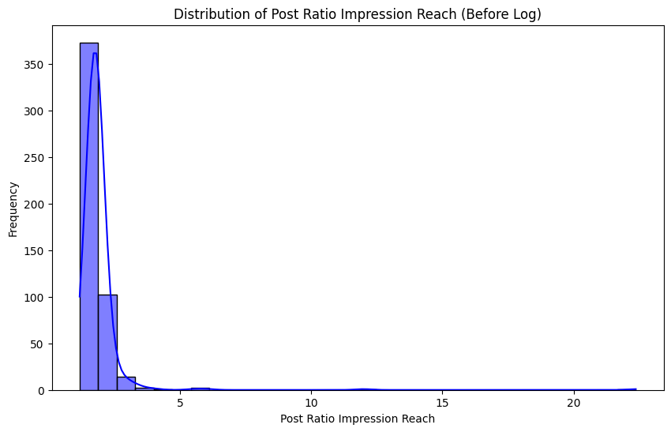

```python
plt.figure(figsize=(10, 6))
sns.histplot(df['post_ratio_imp_reach'], kde=True, color='blue', bins=30)
plt.title('Distribution of Post Ratio Impression Reach (Before Log)')
plt.xlabel('Post Ratio Impression Reach')
plt.ylabel('Frequency')
plt.show()
```

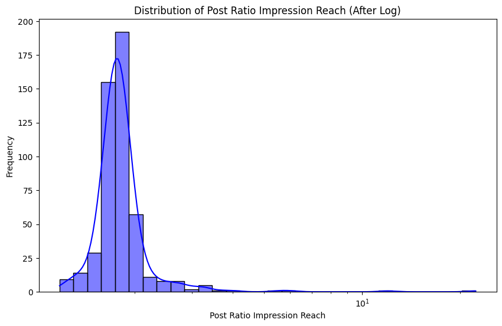

```python
plt.figure(figsize=(10, 6))
sns.histplot(df['post_ratio_imp_reach'], kde=True, color='blue', bins=30,log_scale=True)
plt.title('Distribution of Post Ratio Impression Reach (After Log)')
plt.xlabel('Post Ratio Impression Reach')
plt.ylabel('Frequency')
plt.show()
```

```python
df.loc[df['post_ratio_imp_rach_likes'] > 4]
```

|  | page_total_likes | post_type | category | post_month | post_weekday | post_hour | paid | total_interactions | liked_group | post_ratio_imp_reach | post_ratio_imp_rach_likes | post_ratio_engaged_consumers | post_ratio_engaged_consumption |
| --- | --- | --- | --- | --- | --- | --- | --- | --- | --- | --- | --- | --- | --- |
| 61 | 138185 | Photo | 1 | 11 | 3 | 2 | 1.0 | 162 | High | 3.231615 | 4.302031 | 0.814286 | 2.751445 |
| 415 | 104070 | Photo | 1 | 3 | 4 | 7 | 0.0 | 249 | Low | 22.370285 | 22.904255 | 0.895342 | 1.696629 |
| 437 | 100732 | Photo | 1 | 3 | 6 | 10 | 0.0 | 149 | Low | 3.721280 | 5.525334 | 0.923525 | 4.433684 |
| 442 | 98195 | Photo | 3 | 3 | 4 | 13 | 0.0 | 771 | Low | 5.545447 | 5.998372 | 0.726587 | 1.490712 |
| 449 | 93684 | Photo | 1 | 2 | 6 | 13 | 1.0 | 266 | Low | 6.017741 | 6.303886 | 0.925185 | 2.388307 |
| 460 | 92507 | Photo | 3 | 2 | 1 | 13 | 0.0 | 1873 | Low | 11.991931 | 13.658419 | 0.789173 | 1.931195 |

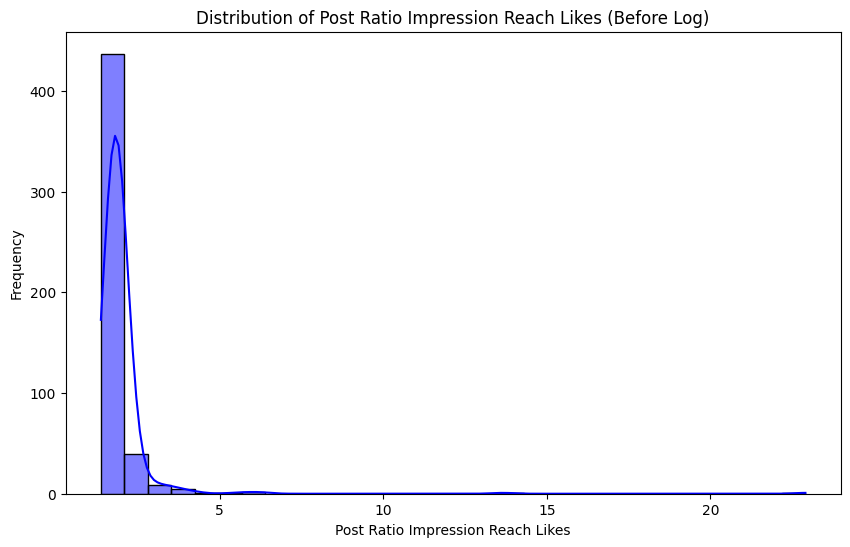

```python
plt.figure(figsize=(10, 6))
sns.histplot(df['post_ratio_imp_rach_likes'], kde=True, color='blue', bins=30)
plt.title('Distribution of Post Ratio Impression Reach Likes (Before Log)')
plt.xlabel('Post Ratio Impression Reach Likes')
plt.ylabel('Frequency')
plt.show()
```

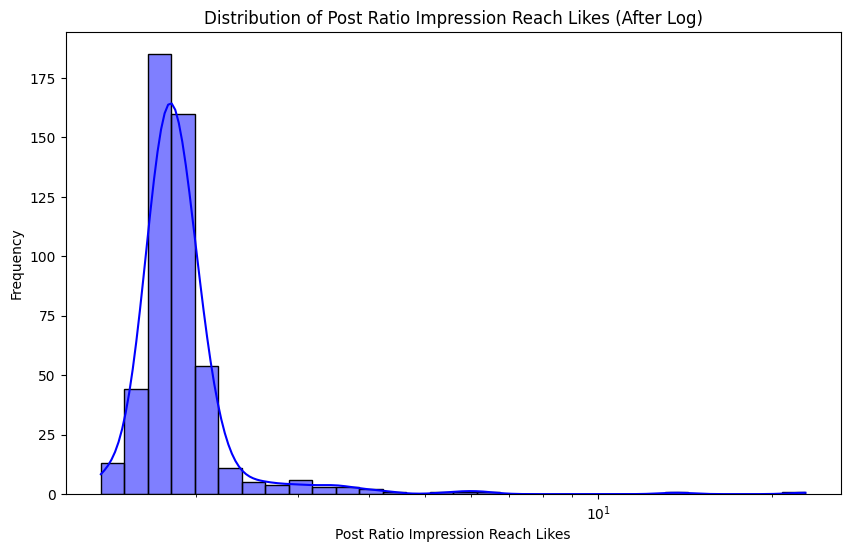

```python
plt.figure(figsize=(10, 6))
sns.histplot(df['post_ratio_imp_rach_likes'], kde=True, color='blue', bins=30,log_scale=True)
plt.title('Distribution of Post Ratio Impression Reach Likes (After Log)')
plt.xlabel('Post Ratio Impression Reach Likes')
plt.ylabel('Frequency')
plt.show()
```

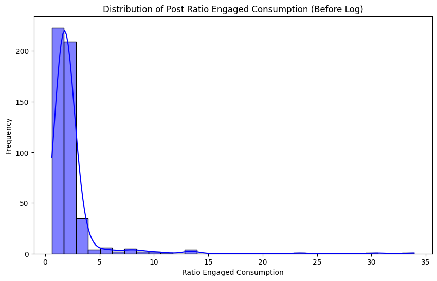

```python
plt.figure(figsize=(10, 6))
sns.histplot(df['post_ratio_engaged_consumption'], kde=True, color='blue', bins=30)
plt.title('Distribution of Post Ratio Engaged Consumption (Before Log)')
plt.xlabel('Ratio Engaged Consumption')
plt.ylabel('Frequency')
plt.show()
```

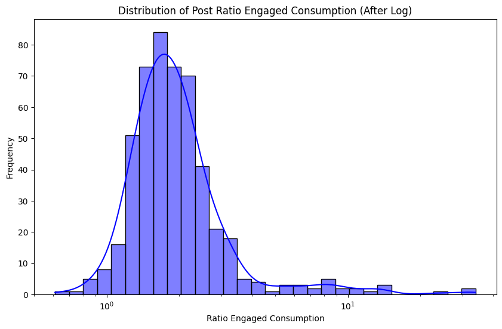

```python
plt.figure(figsize=(10, 6))
sns.histplot(df['post_ratio_engaged_consumption'], kde=True, color='blue', bins=30,log_scale=True)
plt.title('Distribution of Post Ratio Engaged Consumption (After Log)')
plt.xlabel('Ratio Engaged Consumption')
plt.ylabel('Frequency')
plt.show()
```

##### Applying Log on Dataframe

1. As we see we have made differences in Visualization

###### But the main Questions What does Log do to our data?

1. as we see we have the `22.8` outlier and second gratest number is `13.65` there's a quite gap between them
2. so what it does `22.8` will stay on the Top that won't be changed the rank will stay the same
3. but the effectiveness of it will be changed or the gap between the values will be shrinked

```python
df['post_ratio_imp_reach_log'] =np.log1p(df['post_ratio_imp_reach'])
df['post_ratio_imp_reach_like_log'] =np.log1p(df['post_ratio_imp_rach_likes'])
df['post_ratio_engaged_consumption_log'] =np.log1p(df['post_ratio_engaged_consumption'])
```

```python
df.describe()
```

|  | page_total_likes | category | post_month | post_weekday | post_hour | paid | total_interactions | post_ratio_imp_reach | post_ratio_imp_rach_likes | post_ratio_engaged_consumers | post_ratio_engaged_consumption | post_ratio_imp_reach_log | post_ratio_imp_reach_like_log | post_ratio_engaged_consumption_log |
| --- | --- | --- | --- | --- | --- | --- | --- | --- | --- | --- | --- | --- | --- | --- |
| count | 496.000000 | 496.000000 | 496.000000 | 496.000000 | 496.000000 | 496.000000 | 496.000000 | 496.000000 | 496.000000 | 496.000000 | 496.000000 | 496.000000 | 496.000000 | 496.000000 |
| mean | 123489.516129 | 1.883065 | 7.086694 | 4.143145 | 7.832661 | 0.278226 | 211.606855 | 1.885393 | 1.972814 | 0.864408 | 2.345722 | 1.037933 | 1.065713 | 1.105461 |
| std | 16000.557823 | 0.851876 | 3.276261 | 2.034469 | 4.378347 | 0.448578 | 381.252265 | 1.103434 | 1.175253 | 0.121996 | 2.669812 | 0.163646 | 0.171456 | 0.363115 |
| min | 81370.000000 | 1.000000 | 1.000000 | 1.000000 | 1.000000 | 0.000000 | 0.000000 | 1.172763 | 1.365748 | 0.357304 | 0.609649 | 0.775999 | 0.861094 | 0.476016 |
| 25% | 113028.000000 | 1.000000 | 4.000000 | 2.000000 | 3.000000 | 0.000000 | 71.000000 | 1.665130 | 1.724681 | 0.814072 | 1.484825 | 0.980253 | 1.002351 | 0.910202 |
| 50% | 129600.000000 | 2.000000 | 7.000000 | 4.000000 | 9.000000 | 0.000000 | 122.500000 | 1.761861 | 1.816318 | 0.905741 | 1.799556 | 1.015905 | 1.035430 | 1.029461 |
| 75% | 136393.000000 | 3.000000 | 10.000000 | 6.000000 | 11.000000 | 1.000000 | 228.500000 | 1.875817 | 1.946658 | 0.953346 | 2.261318 | 1.056337 | 1.080672 | 1.182131 |
| max | 139441.000000 | 3.000000 | 12.000000 | 7.000000 | 23.000000 | 1.000000 | 6334.000000 | 22.370285 | 22.904255 | 1.000000 | 33.926244 | 3.151465 | 3.174056 | 3.553239 |

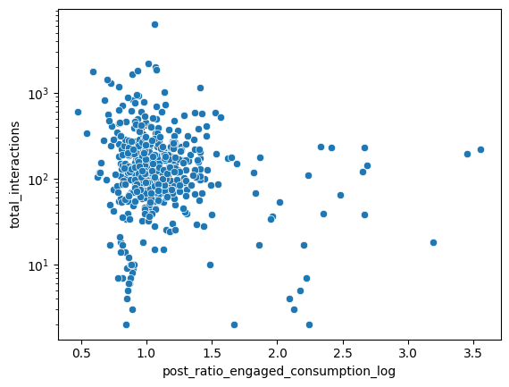

```python
sns.scatterplot(y= 'total_interactions',x='post_ratio_engaged_consumption_log',data=df)
plt.yscale('log')
```

```python
df.drop(columns=['post_ratio_imp_reach','post_ratio_imp_rach_likes','post_ratio_engaged_consumption','liked_group'],inplace=True)
```

```python
df.describe()
```

|  | page_total_likes | category | post_month | post_weekday | post_hour | paid | total_interactions | post_ratio_engaged_consumers | post_ratio_imp_reach_log | post_ratio_imp_reach_like_log | post_ratio_engaged_consumption_log |
| --- | --- | --- | --- | --- | --- | --- | --- | --- | --- | --- | --- |
| count | 496.000000 | 496.000000 | 496.000000 | 496.000000 | 496.000000 | 496.000000 | 496.000000 | 496.000000 | 496.000000 | 496.000000 | 496.000000 |
| mean | 123489.516129 | 1.883065 | 7.086694 | 4.143145 | 7.832661 | 0.278226 | 211.606855 | 0.864408 | 1.037933 | 1.065713 | 1.105461 |
| std | 16000.557823 | 0.851876 | 3.276261 | 2.034469 | 4.378347 | 0.448578 | 381.252265 | 0.121996 | 0.163646 | 0.171456 | 0.363115 |
| min | 81370.000000 | 1.000000 | 1.000000 | 1.000000 | 1.000000 | 0.000000 | 0.000000 | 0.357304 | 0.775999 | 0.861094 | 0.476016 |
| 25% | 113028.000000 | 1.000000 | 4.000000 | 2.000000 | 3.000000 | 0.000000 | 71.000000 | 0.814072 | 0.980253 | 1.002351 | 0.910202 |
| 50% | 129600.000000 | 2.000000 | 7.000000 | 4.000000 | 9.000000 | 0.000000 | 122.500000 | 0.905741 | 1.015905 | 1.035430 | 1.029461 |
| 75% | 136393.000000 | 3.000000 | 10.000000 | 6.000000 | 11.000000 | 1.000000 | 228.500000 | 0.953346 | 1.056337 | 1.080672 | 1.182131 |
| max | 139441.000000 | 3.000000 | 12.000000 | 7.000000 | 23.000000 | 1.000000 | 6334.000000 | 1.000000 | 3.151465 | 3.174056 | 3.553239 |

```python
df.to_csv('Facebook_metrics_Regression.csv',index=False)
```